# groupProject

### BANA 6620 - Group Project : Online News Popularity

##### Team Members :

Pushpa Sowmya Narne

Vishnu Vardhan Guttikonda

Praneeth Rayudu Chinimilli

Dheeraj Lagishetty

### Exploratory Data Analysis

```python
# Importing data into python
import pandas as pd
onlineNewsPopularityData = pd.read_csv("OnlineNewsPopularity.csv")

# Changing the name of dataFrame
olDF = onlineNewsPopularityData
```

```python
# Columns in the dataset
olDF.columns
```

```
Index(['url', ' timedelta', ' n_tokens_title', ' n_tokens_content',
       ' n_unique_tokens', ' n_non_stop_words', ' n_non_stop_unique_tokens',
       ' num_hrefs', ' num_self_hrefs', ' num_imgs', ' num_videos',
       ' average_token_length', ' num_keywords', ' data_channel_is_lifestyle',
       ' data_channel_is_entertainment', ' data_channel_is_bus',
       ' data_channel_is_socmed', ' data_channel_is_tech',
       ' data_channel_is_world', ' kw_min_min', ' kw_max_min', ' kw_avg_min',
       ' kw_min_max', ' kw_max_max', ' kw_avg_max', ' kw_min_avg',
       ' kw_max_avg', ' kw_avg_avg', ' self_reference_min_shares',
       ' self_reference_max_shares', ' self_reference_avg_sharess',
       ' weekday_is_monday', ' weekday_is_tuesday', ' weekday_is_wednesday',
       ' weekday_is_thursday', ' weekday_is_friday', ' weekday_is_saturday',
       ' weekday_is_sunday', ' is_weekend', ' LDA_00', ' LDA_01', ' LDA_02',
       ' LDA_03', ' LDA_04', ' global_subjectivity',
       ' global_sentiment_polarity', ' global_rate_positive_words',
       ' global_rate_negative_words', ' rate_positive_words',
       ' rate_negative_words', ' avg_positive_polarity',
       ' min_positive_polarity', ' max_positive_polarity',
       ' avg_negative_polarity', ' min_negative_polarity',
       ' max_negative_polarity', ' title_subjectivity',
       ' title_sentiment_polarity', ' abs_title_subjectivity',
       ' abs_title_sentiment_polarity', ' shares'],
      dtype='object')
```

```python
# Dimensions of the dataFrame
olDF.shape
```

```
(39644, 61)
```

```python
# Top 5 rows of the dataFrame

olDF.head()
```

|  | url | timedelta | n_tokens_title | n_tokens_content | n_unique_tokens | n_non_stop_words | n_non_stop_unique_tokens | num_hrefs | num_self_hrefs | num_imgs | ... | min_positive_polarity | max_positive_polarity | avg_negative_polarity | min_negative_polarity | max_negative_polarity | title_subjectivity | title_sentiment_polarity | abs_title_subjectivity | abs_title_sentiment_polarity | shares |
| --- | --- | --- | --- | --- | --- | --- | --- | --- | --- | --- | --- | --- | --- | --- | --- | --- | --- | --- | --- | --- | --- |
| 0 | http://mashable.com/2013/01/07/amazon-instant-... | 731.0 | 12.0 | 219.0 | 0.663594 | 1.0 | 0.815385 | 4.0 | 2.0 | 1.0 | ... | 0.100000 | 0.7 | -0.350000 | -0.600 | -0.200000 | 0.500000 | -0.187500 | 0.000000 | 0.187500 | 593 |
| 1 | http://mashable.com/2013/01/07/ap-samsung-spon... | 731.0 | 9.0 | 255.0 | 0.604743 | 1.0 | 0.791946 | 3.0 | 1.0 | 1.0 | ... | 0.033333 | 0.7 | -0.118750 | -0.125 | -0.100000 | 0.000000 | 0.000000 | 0.500000 | 0.000000 | 711 |
| 2 | http://mashable.com/2013/01/07/apple-40-billio... | 731.0 | 9.0 | 211.0 | 0.575130 | 1.0 | 0.663866 | 3.0 | 1.0 | 1.0 | ... | 0.100000 | 1.0 | -0.466667 | -0.800 | -0.133333 | 0.000000 | 0.000000 | 0.500000 | 0.000000 | 1500 |
| 3 | http://mashable.com/2013/01/07/astronaut-notre... | 731.0 | 9.0 | 531.0 | 0.503788 | 1.0 | 0.665635 | 9.0 | 0.0 | 1.0 | ... | 0.136364 | 0.8 | -0.369697 | -0.600 | -0.166667 | 0.000000 | 0.000000 | 0.500000 | 0.000000 | 1200 |
| 4 | http://mashable.com/2013/01/07/att-u-verse-apps/ | 731.0 | 13.0 | 1072.0 | 0.415646 | 1.0 | 0.540890 | 19.0 | 19.0 | 20.0 | ... | 0.033333 | 1.0 | -0.220192 | -0.500 | -0.050000 | 0.454545 | 0.136364 | 0.045455 | 0.136364 | 505 |

5 rows × 61 columns

```python
# Describe data

olDF.describe()
```

|  | timedelta | n_tokens_title | n_tokens_content | n_unique_tokens | n_non_stop_words | n_non_stop_unique_tokens | num_hrefs | num_self_hrefs | num_imgs | num_videos | ... | min_positive_polarity | max_positive_polarity | avg_negative_polarity | min_negative_polarity | max_negative_polarity | title_subjectivity | title_sentiment_polarity | abs_title_subjectivity | abs_title_sentiment_polarity | shares |
| --- | --- | --- | --- | --- | --- | --- | --- | --- | --- | --- | --- | --- | --- | --- | --- | --- | --- | --- | --- | --- | --- |
| count | 39644.000000 | 39644.000000 | 39644.000000 | 39644.000000 | 39644.000000 | 39644.000000 | 39644.000000 | 39644.000000 | 39644.000000 | 39644.000000 | ... | 39644.000000 | 39644.000000 | 39644.000000 | 39644.000000 | 39644.000000 | 39644.000000 | 39644.000000 | 39644.000000 | 39644.000000 | 39644.000000 |
| mean | 354.530471 | 10.398749 | 546.514731 | 0.548216 | 0.996469 | 0.689175 | 10.883690 | 3.293638 | 4.544143 | 1.249874 | ... | 0.095446 | 0.756728 | -0.259524 | -0.521944 | -0.107500 | 0.282353 | 0.071425 | 0.341843 | 0.156064 | 3395.380184 |
| std | 214.163767 | 2.114037 | 471.107508 | 3.520708 | 5.231231 | 3.264816 | 11.332017 | 3.855141 | 8.309434 | 4.107855 | ... | 0.071315 | 0.247786 | 0.127726 | 0.290290 | 0.095373 | 0.324247 | 0.265450 | 0.188791 | 0.226294 | 11626.950749 |
| min | 8.000000 | 2.000000 | 0.000000 | 0.000000 | 0.000000 | 0.000000 | 0.000000 | 0.000000 | 0.000000 | 0.000000 | ... | 0.000000 | 0.000000 | -1.000000 | -1.000000 | -1.000000 | 0.000000 | -1.000000 | 0.000000 | 0.000000 | 1.000000 |
| 25% | 164.000000 | 9.000000 | 246.000000 | 0.470870 | 1.000000 | 0.625739 | 4.000000 | 1.000000 | 1.000000 | 0.000000 | ... | 0.050000 | 0.600000 | -0.328383 | -0.700000 | -0.125000 | 0.000000 | 0.000000 | 0.166667 | 0.000000 | 946.000000 |
| 50% | 339.000000 | 10.000000 | 409.000000 | 0.539226 | 1.000000 | 0.690476 | 8.000000 | 3.000000 | 1.000000 | 0.000000 | ... | 0.100000 | 0.800000 | -0.253333 | -0.500000 | -0.100000 | 0.150000 | 0.000000 | 0.500000 | 0.000000 | 1400.000000 |
| 75% | 542.000000 | 12.000000 | 716.000000 | 0.608696 | 1.000000 | 0.754630 | 14.000000 | 4.000000 | 4.000000 | 1.000000 | ... | 0.100000 | 1.000000 | -0.186905 | -0.300000 | -0.050000 | 0.500000 | 0.150000 | 0.500000 | 0.250000 | 2800.000000 |
| max | 731.000000 | 23.000000 | 8474.000000 | 701.000000 | 1042.000000 | 650.000000 | 304.000000 | 116.000000 | 128.000000 | 91.000000 | ... | 1.000000 | 1.000000 | 0.000000 | 0.000000 | 0.000000 | 1.000000 | 1.000000 | 0.500000 | 1.000000 | 843300.000000 |

8 rows × 60 columns

```python
# Unique values in the columns

olDF.nunique()
```

```
url                              39644
 timedelta                         724
 n_tokens_title                     20
 n_tokens_content                 2406
 n_unique_tokens                 27281
                                 ...
 title_subjectivity                673
 title_sentiment_polarity          813
 abs_title_subjectivity            532
 abs_title_sentiment_polarity      653
 shares                           1454
Length: 61, dtype: int64
```

### Checking if there are any null values in the dataset

```python
olDF.isnull().sum()
```

```
url                              0
 timedelta                       0
 n_tokens_title                  0
 n_tokens_content                0
 n_unique_tokens                 0
                                ..
 title_subjectivity              0
 title_sentiment_polarity        0
 abs_title_subjectivity          0
 abs_title_sentiment_polarity    0
 shares                          0
Length: 61, dtype: int64
```

**Observations:** There are no null values in the dataset

### Data Cleaning

**Sorting the unwanted list of columns**

```python
reqCol = [2,3,4,6,7,9,10,11,12,13,14,15,16,17,18,31,32,33,34,35,36,37,38,60]
notReqCol = []
for i in range(61):
    if i not in reqCol:
        notReqCol.append(olDF.columns[i])
print(notReqCol)
```

[output not shown]

**Dropping the unwanted columns**

```python
olDF.drop([col for col in notReqCol if col in olDF],
        axis=1, inplace=True)
```

```python
# Dimensions of the dataset post dropping the columns
olDF.shape
```

```
(39644, 24)
```

```python
# Columns in the dataset after dropping the unwanted variables
olDF.columns
```

```
Index([' n_tokens_title', ' n_tokens_content', ' n_unique_tokens',
       ' n_non_stop_unique_tokens', ' num_hrefs', ' num_imgs', ' num_videos',
       ' average_token_length', ' num_keywords', ' data_channel_is_lifestyle',
       ' data_channel_is_entertainment', ' data_channel_is_bus',
       ' data_channel_is_socmed', ' data_channel_is_tech',
       ' data_channel_is_world', ' weekday_is_monday', ' weekday_is_tuesday',
       ' weekday_is_wednesday', ' weekday_is_thursday', ' weekday_is_friday',
       ' weekday_is_saturday', ' weekday_is_sunday', ' is_weekend', ' shares'],
      dtype='object')
```

**Creating new column as NewsPopularity based on shares**

```python
newsPopularity = []
for i in range(len(olDF)):
    if olDF[' shares'][i] <= 1500:
        newsPopularity.append('Poor')
    elif olDF[' shares'][i] > 1500 and olDF[' shares'][i] <= 10000:
        newsPopularity.append('Average')
    elif olDF[' shares'][i] > 10000 and olDF[' shares'][i] <= 50000:
        newsPopularity.append('Good')
    elif olDF[' shares'][i] > 50000 and olDF[' shares'][i] <= 100000:
        newsPopularity.append('Excellent')
    else:
        newsPopularity.append('Exceptional')

olDF = pd.concat([olDF, pd.DataFrame(newsPopularity, columns=['NewsPopularity'])], axis=1)
```

```python
# view of NewsPopularity column values
olDF["NewsPopularity"].head(10)
```

```
0       Poor
1       Poor
2       Poor
3       Poor
4       Poor
5       Poor
6       Poor
7       Poor
8    Average
9       Poor
Name: NewsPopularity, dtype: object
```

### Relationship Analysis

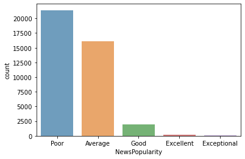

```python
# Count of shares based on NewsPopularity
import seaborn as sns
import matplotlib.pyplot as plt
sns.countplot(x='NewsPopularity',data=olDF,alpha=0.7)
```

```python
# Articles published on particular days
print("Day         Count")
print("\nMonday     ",olDF[" weekday_is_monday"].sum())
print("Tuesday    ",olDF[" weekday_is_tuesday"].sum())
print("Wednesday  ",olDF[" weekday_is_wednesday"].sum())
print("Thursday   ",olDF[" weekday_is_thursday"].sum())
print("Friday     ",olDF[" weekday_is_friday"].sum())
print("Saturday   ",olDF[" weekday_is_saturday"].sum())
print("Sunday     ",olDF[" weekday_is_sunday"].sum())
```

```
Day         Count

Monday      6661.0
Tuesday     7390.0
Wednesday   7435.0
Thursday    7267.0
Friday      5701.0
Saturday    2453.0
Sunday      2737.0
```

**Observations:** More articles are being published on weekdays (mainly Tuesday,Wednesday,Thursday) compared to weekends

```python
# Popularity among data channels
olDF.groupby(["NewsPopularity"]).agg({" data_channel_is_lifestyle":['sum']," data_channel_is_entertainment":['sum']," data_channel_is_bus":['sum']," data_channel_is_socmed":['sum']," data_channel_is_tech":['sum']," data_channel_is_world":['sum']})
```

| NewsPopularity | data_channel_is_lifestyle sum | data_channel_is_entertainment sum | data_channel_is_bus sum | data_channel_is_socmed sum | data_channel_is_tech sum | data_channel_is_world sum |
| --- | --- | --- | --- | --- | --- | --- |
| Average | 989.0 | 2042.0 | 2619.0 | 1439.0 | 3760.0 | 2422.0 |
| Excellent | 5.0 | 28.0 | 13.0 | 6.0 | 12.0 | 16.0 |
| Exceptional | 3.0 | 7.0 | 11.0 | 1.0 | 2.0 | 6.0 |
| Good | 133.0 | 354.0 | 169.0 | 123.0 | 293.0 | 232.0 |
| Poor | 969.0 | 4626.0 | 3446.0 | 754.0 | 3279.0 | 5751.0 |

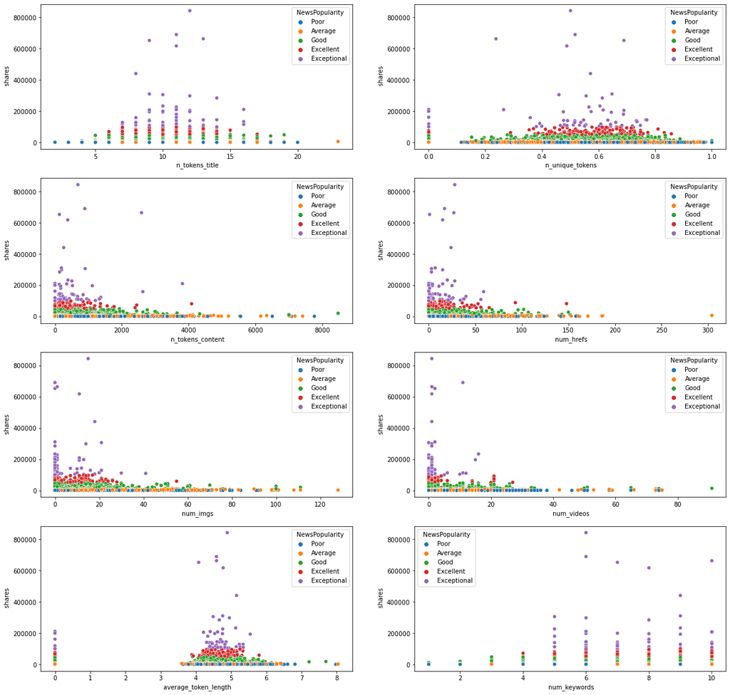

```python
# Populairty based on n_tokens_title, n_unique_tokens, n_tokens_content, num_hrefs

tokens_data = olDF[olDF[' n_unique_tokens'] != 701]   # excluding the anamoly
fig, axs = plt.subplots(figsize=(20,20), nrows=4,ncols=2)
sns.scatterplot(x = ' n_tokens_title', y = ' shares', hue = 'NewsPopularity', data = olDF, ax=axs[0][0])
sns.scatterplot(x = ' n_unique_tokens', y = ' shares', hue = 'NewsPopularity', data = tokens_data, ax=axs[0][1])
sns.scatterplot(x = ' n_tokens_content', y = ' shares', hue = 'NewsPopularity', data = olDF, ax=axs[1][0])
sns.scatterplot(x = ' num_hrefs', y = ' shares', hue = 'NewsPopularity', data = olDF, ax=axs[1][1])
sns.scatterplot(x = ' num_imgs', y = ' shares', hue = 'NewsPopularity', data = olDF, ax=axs[2][0])
sns.scatterplot(x = ' num_videos', y = ' shares', hue = 'NewsPopularity', data = olDF, ax=axs[2][1])
sns.scatterplot(x = ' average_token_length', y = ' shares', hue = 'NewsPopularity', data = olDF, ax=axs[3][0])
sns.scatterplot(x = ' num_keywords', y = ' shares', hue = 'NewsPopularity', data = olDF, ax=axs[3][1])
```

### Recommendations for Good Articles based on Exploratoty data analysis:

1. n_tokens_title should be between 6 - 17 words
2. n_tokens_content should be less than or equal to 2000 words
3. n_unique_tokens (rate of unique words in the content) should be between 0.4 - 0.8
4. num_hrefs is between 1 and 50 referrence links
5. num_imgs should between 1 - 30 images
6. num_videos should be between 0 - 20 vidoes.
7. average_token_length should be between 4 - 5
8. The number of keywords in the metedata really influences the shares to a margin. The higher the value the better the shares
9. The best articles ranking with highest share popularity are:
1. Entertainment
2. Technical
3. World
4. Business
5. Lifestyle
6. Social media
10. Most popular articles are usually posted mainly on Wednesday (tuesday or thursday). Sundays and Saturdays (Weekends generally) are the worst days to publish an article.

### Fitting Regression Models

```python
'''
Importing Libraries
'''
import pandas as pd
import numpy as np
import matplotlib.pyplot as plt
from sklearn import linear_model
from sklearn.ensemble import RandomForestRegressor
from sklearn.metrics import mean_squared_error
from sklearn.metrics import r2_score
from sklearn.preprocessing import StandardScaler
from sklearn.metrics import accuracy_score
from sklearn.decomposition import PCA
from sklearn.ensemble import RandomForestClassifier
from sklearn.neighbors import KNeighborsClassifier
```

```python
np.random.seed(1)

'''
Reading csv data
'''
newsDF = pd.read_csv('OnlineNewsPopularity.csv')
newsDF.rename(columns=lambda x: x.strip(), inplace=True)
del newsDF["url"]
```

```python
'''
resultsDF contains mse, r2, adjR2, accuracyscores
'''
resultsDF = pd.DataFrame(columns = ["Description","Features","MSE", "R2", "AdjR2", "AccuracyScore"])
```

```python
'''
column names list
'''
colNameList = []
for colName in newsDF:
    colNameList.append(colName)
```

```python
'''
Fetching the training rows and testing rows indicies
'''
numberOfRows = len(newsDF)
randomShuffledRows = np.random.permutation(numberOfRows)
trainingRows = randomShuffledRows[0:int(numberOfRows * 0.75)]
testingRows = randomShuffledRows[int(numberOfRows * 0.75)+1:]
```

### Common Functions used by the regression models

```python
'''
Function - to split the data into training and test rows
'''
def splitData(inputDF, nTrainRows, nTestRows):
    X_train = inputDF.iloc[nTrainRows,0:-1]
    Y_train = inputDF.iloc[nTrainRows,-1]
    X_test = inputDF.iloc[nTestRows, 0:-1]
    Y_test = inputDF.iloc[nTestRows,-1]
    return X_train, Y_train, X_test, Y_test

'''
Fitting the regression models
'''
def fitModel(X_train,Y_train,modelName):
    if modelName == 'linear':
        model = linear_model.LinearRegression()
    elif modelName == 'logistic':
        model = linear_model.LogisticRegression(solver='lbfgs',max_iter=300)
    elif modelName == 'randomForest':
        model = RandomForestRegressor(n_estimators = 100)
    model.fit(X_train,Y_train)
    return model

'''
Predicting the model on X_test
'''
def predictModel(model, X_test):
    Y_Predict = model.predict(X_test)
    return Y_Predict
'''
Calculating the mean squared error
'''
def meanSquareErr(Y_Predict, Y_test):
    return mean_squared_error(Y_Predict, Y_test)

'''
Calculating the R2 score
'''
def r2Score(Y_Predict, Y_test):
    return r2_score(Y_Predict, Y_test)
'''
Calculating the AdjR2
'''
def adjR2Score(X_test,r2Score):
    n = X_test.shape[0]
    p = X_test.shape[1]
    return 1 - (1-r2Score) * (n-1)/(n-p-1)

'''
Calculating the accuracy_score
'''
def accuracyScore(Y_Predict, Y_test):
    return str(100*accuracy_score(Y_Predict, Y_test))

'''
Fetching the top N features of a model
'''
def getTopFeatures(model, noOfFeatures, featureNameList, modelName):
    modelTopFeaturesDF = pd.DataFrame(columns = ["FeatureName","Coefficient"])
    lenOfFeatures = 0
    if modelName == 'linear':
        featureCoef = model.coef_
        lenOfFeatures = len(featureCoef)
        for x in range(lenOfFeatures):
            modelTopFeaturesDF = modelTopFeaturesDF.append({"FeatureName":featureNameList[x],"Coefficient":featureCoef[x]}, ignore_index= True)
    elif modelName == 'logistic':
        featureCoef = model.coef_
        lenOfFeatures = len(featureCoef[0])
        for x in range(lenOfFeatures):
            modelTopFeaturesDF = modelTopFeaturesDF.append({"FeatureName":featureNameList[x],"Coefficient":featureCoef[0][x]}, ignore_index= True)
    elif modelName == 'randomForest':
        featureCoef = model.feature_importances_
        lenOfFeatures = len(featureCoef)
        for x in range(lenOfFeatures):
            modelTopFeaturesDF = modelTopFeaturesDF.append({"FeatureName":featureNameList[x],"Coefficient":featureCoef[x]}, ignore_index= True)
    topFeaturesDF = (modelTopFeaturesDF.iloc[(-modelTopFeaturesDF['Coefficient'].abs()).argsort()]).iloc[0:noOfFeatures,:]
    return topFeaturesDF

'''
Generating a new dataframe with top N features
'''
def getDFWithTopFeatures(inputTopFeaturesDF, inputDF):
    dfWithTopFeatures = pd.DataFrame(data=None)
    for i in range(len(inputTopFeaturesDF)):
        dfWithTopFeatures[inputTopFeaturesDF.iloc[i,0]] = inputDF[inputTopFeaturesDF.iloc[i,0]] #LDA_01
    dfWithTopFeatures["shares"] = inputDF.iloc[:,-1]
    return dfWithTopFeatures

'''
Normalizing the input dataframe using standard_scaler
'''
def getNormalizeDataFrame(inputDF):
    normalizedDF = inputDF.copy()
    scaler = StandardScaler()
    scaled_values = scaler.fit_transform(normalizedDF)
    normalizedDF.loc[:,:] = scaled_values
    return normalizedDF
```

**Fitting Linear Regression Models for whole dataset (before and after Normalization)**

```python
'''
LinearRegression on the whole dataset without Normalization
'''
xTrain, yTrain, xTest, yTest = splitData(newsDF,trainingRows, testingRows)
reg = fitModel(xTrain,yTrain, modelName = 'linear')
yPredict = predictModel(reg, xTest)
mse = meanSquareErr(yPredict,yTest)
r2 = r2Score(yPredict,yTest)
adjR2 = adjR2Score(xTest, r2)
accScore = "NA"

resultsDF = resultsDF.append({"Description" : "LinearRegression",
                              "Features" :"All",
                              "MSE":mse,
                              "R2" : r2,
                              "AdjR2" : adjR2,
                              "AccuracyScore" : accScore},
                             ignore_index = True
                             )

'''
LinearRegression on the whole dataset WITH Normalization
'''
newsNormalizedDF = getNormalizeDataFrame(newsDF)
xTrain, yTrain, xTest, yTest = splitData(newsNormalizedDF,trainingRows, testingRows)
reg = fitModel(xTrain,yTrain, modelName = 'linear')
yPredict = predictModel(reg, xTest)
mse = meanSquareErr(yPredict,yTest)
r2 = r2Score(yPredict,yTest)
adjR2 = adjR2Score(xTest, r2)
accScore = "NA"

resultsDF = resultsDF.append({"Description" : "LinearRegression",
                              "Features" :"Normalized",
                              "MSE":mse,
                              "R2" : r2,
                              "AdjR2" : adjR2,
                              "AccuracyScore" : accScore},
                             ignore_index = True
                             )
'''
Printing resultsDF
'''
resultsDF
```

|  | Description | Features | MSE | R2 | AdjR2 | AccuracyScore |
| --- | --- | --- | --- | --- | --- | --- |
| 0 | LinearRegression | All | 1.431228e+08 | -42.915146 | -43.178191 | NA |
| 1 | LinearRegression | Normalized | 1.058737e+00 | -42.915146 | -43.178191 | NA |

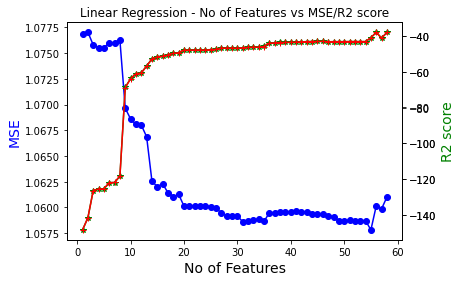

```python
'''
LinearRegression finding ideal number of features against adjusted R2
'''
newsNormalizedDF = getNormalizeDataFrame(newsDF)
xTrain, yTrain, xTest, yTest = splitData(newsNormalizedDF,trainingRows, testingRows)
reg = fitModel(xTrain,yTrain, modelName = 'linear')

resultTopFeatures = pd.DataFrame(columns = ["Features","MSE","R2", "AdjR2", "AccuracyScore"])
for nfeatures in range(1,len(reg.coef_)):
    topFeaturesDF = getTopFeatures(reg, nfeatures, colNameList, modelName = 'linear')
    newsTopFeaturesDF = getDFWithTopFeatures(topFeaturesDF, newsNormalizedDF)
    xTrain, yTrain, xTest, yTest = splitData(newsTopFeaturesDF,trainingRows, testingRows)
    regTopFeatures = fitModel(xTrain,yTrain, modelName = 'linear')
    yPredict = predictModel(regTopFeatures, xTest)
    mse = meanSquareErr(yPredict,yTest)
    r2 = r2Score(yPredict,yTest)
    adjR2 = adjR2Score(xTest, r2)
    accScore = "NA"
    resultTopFeatures = resultTopFeatures.append({"Features" : int(nfeatures),
                                                  "MSE" : mse ,
                                                  "R2" :r2 ,
                                                  "AdjR2" : adjR2,
                                                  "AccuracyScore" : accScore}
                                                  , ignore_index = True)

fig,ax = plt.subplots()
ax.plot(resultTopFeatures["Features"], resultTopFeatures["MSE"], marker = 'o', color = 'b')
ax.set_xlabel("No of Features",fontsize=14)
ax.set_ylabel("MSE",color="blue",fontsize=14)
ax2=ax.twinx()
ax2.plot(resultTopFeatures["Features"], resultTopFeatures["AdjR2"], marker = '*', color = 'g')
ax2.set_ylabel("R2 score",color="green",fontsize=14)
ax3=ax.twinx()
ax3.plot(resultTopFeatures["Features"], resultTopFeatures["R2"], marker = '+', color = 'r')
plt.title('Linear Regression - No of Features vs MSE/R2 score')
```

**Observations:** MSE and R2 scores remained more or less constant when the number of features >= 20

```python
'''
Listing the top 20 features of Linear Regression Model
'''
topFeaturesDF.iloc[0:21,:]
```

|  | FeatureName | Coefficient |
| --- | --- | --- |
| 41 | LDA_03 | -15.595906 |
| 42 | LDA_04 | -15.276946 |
| 40 | LDA_02 | -14.930077 |
| 38 | LDA_00 | -13.888720 |
| 39 | LDA_01 | -11.614417 |
| 3 | n_unique_tokens | 0.943916 |
| 4 | n_non_stop_words | -0.667813 |
| 5 | n_non_stop_unique_tokens | -0.539390 |
| 26 | kw_avg_avg | 0.175531 |
| 25 | kw_max_avg | -0.098809 |
| 13 | data_channel_is_entertainment | -0.040764 |
| 14 | data_channel_is_bus | -0.033511 |
| 24 | kw_min_avg | -0.031067 |
| 27 | self_reference_min_shares | 0.030067 |
| 2 | n_tokens_content | 0.026983 |
| 7 | num_self_hrefs | -0.026207 |
| 52 | avg_negative_polarity | -0.026068 |
| 6 | num_hrefs | 0.025958 |
| 28 | self_reference_max_shares | 0.025765 |
| 0 | timedelta | 0.023873 |
| 47 | rate_positive_words | 0.022589 |

```python
'''
LinearRegression on the whole dataset for the Top 20 features with Normalization
'''
newsNormalizedDF = getNormalizeDataFrame(newsDF)
xTrain, yTrain, xTest, yTest = splitData(newsNormalizedDF,trainingRows, testingRows)
reg = fitModel(xTrain,yTrain, modelName = 'linear')
noOfFeatures = 20
topFeaturesDF = getTopFeatures(reg, noOfFeatures, colNameList, modelName = 'linear')
newsTopFeaturesDF = getDFWithTopFeatures(topFeaturesDF, newsNormalizedDF)

xTrain, yTrain, xTest, yTest = splitData(newsTopFeaturesDF,trainingRows, testingRows)
reg = fitModel(xTrain,yTrain, modelName = 'linear')
yPredict = predictModel(reg, xTest)
mse = meanSquareErr(yPredict,yTest)
r2 = r2Score(yPredict,yTest)
adjR2 = adjR2Score(xTest, r2)
accScore = "NA"

resultsDF = resultsDF.append({"Description" : "LinearRegression",
                              "Features" :"Top 20",
                              "MSE":mse,
                              "R2" : r2,
                              "AdjR2" : adjR2,
                              "AccuracyScore" : accScore},
                             ignore_index = True
                             )

'''
Printing resultsDF
'''
resultsDF
```

|  | Description | Features | MSE | R2 | AdjR2 | AccuracyScore |
| --- | --- | --- | --- | --- | --- | --- |
| 0 | LinearRegression | All | 1.431228e+08 | -42.915146 | -43.178191 | NA |
| 1 | LinearRegression | Normalized | 1.058737e+00 | -42.915146 | -43.178191 | NA |
| 2 | LinearRegression | Top 20 | 1.060123e+00 | -47.684181 | -47.782643 | NA |

**Fitting Logistic Regression Models for whole dataset (before and after Normalization)**

```python
'''
Converting the shares column to 0 or 1 based on median
'''
newsLogDF = newsDF.copy()
newsLogDF['shares'] = (newsLogDF['shares'] >= newsLogDF['shares'].median()).astype(int)

'''
Logistic Regression on the whole dataset without Normalization
'''
xTrain, yTrain, xTest, yTest = splitData(newsLogDF,trainingRows, testingRows)
logReg = fitModel(xTrain,yTrain, modelName = 'logistic')
yLogRegPredict = predictModel(logReg, xTest)
logMSE = meanSquareErr(yLogRegPredict,yTest)
logR2 = r2Score(yLogRegPredict,yTest)
logAdjR2 = adjR2Score(xTest, logR2)
accScore = accuracyScore(yLogRegPredict, yTest)

resultsDF = resultsDF.append({"Description" : "LogisticRegression",
                              "Features" :"All",
                              "MSE":logMSE,
                              "R2" : logR2,
                              "AdjR2" : logAdjR2,
                              "AccuracyScore" : accScore
                              },
                             ignore_index = True
                             )

'''
LogisticRegression on the whole dataset WITH Normalization
'''
newsNormalizedDF = getNormalizeDataFrame(newsLogDF)
newsNormalizedDF['shares'] = newsLogDF['shares']
xTrain, yTrain, xTest, yTest = splitData(newsNormalizedDF,trainingRows, testingRows)
logReg = fitModel(xTrain,yTrain, modelName = 'logistic')
yLogRegPredict = predictModel(logReg, xTest)
logMSE = meanSquareErr(yLogRegPredict,yTest)
logR2 = r2Score(yLogRegPredict,yTest)
logAdjR2 = adjR2Score(xTest, logR2)
accScore = accuracyScore(yLogRegPredict, yTest)

resultsDF = resultsDF.append({"Description" : "LogisticRegression",
                              "Features" :"All Normalized",
                              "MSE":logMSE,
                              "R2" : logR2,
                              "AdjR2" : logAdjR2,
                              "AccuracyScore" : accScore},
                             ignore_index = True
                             )

'''
Printing resultsDF
'''
resultsDF
```

|  | Description | Features | MSE | R2 | AdjR2 | AccuracyScore |
| --- | --- | --- | --- | --- | --- | --- |
| 0 | LinearRegression | All | 1.431228e+08 | -42.915146 | -43.178191 | NA |
| 1 | LinearRegression | Normalized | 1.058737e+00 | -42.915146 | -43.178191 | NA |
| 2 | LinearRegression | Top 20 | 1.060123e+00 | -47.684181 | -47.782643 | NA |
| 3 | LogisticRegression | All | 3.880928e-01 | -0.617326 | -0.627013 | 61.19071644803229 |
| 4 | LogisticRegression | All Normalized | 3.446014e-01 | -0.396891 | -0.405258 | 65.53985872855701 |

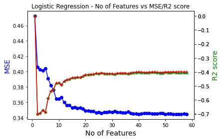

```python
'''
LogisticRegression finding ideal number of features against adjusted R2
'''
newsNormalizedDF = getNormalizeDataFrame(newsLogDF)
newsNormalizedDF['shares'] = newsLogDF['shares']
xTrain, yTrain, xTest, yTest = splitData(newsNormalizedDF,trainingRows, testingRows)
logReg = fitModel(xTrain,yTrain, modelName = 'logistic')

resultTopFeaturesDF = pd.DataFrame(columns = ["Features","MSE","R2", "AdjR2", "AccuracyScore"])
for nfeatures in range(1,len(logReg.coef_[0])):
    topFeaturesDF = getTopFeatures(logReg, nfeatures, colNameList, modelName = 'logistic')
    newsTopFeaturesDF = getDFWithTopFeatures(topFeaturesDF, newsNormalizedDF)
    xTrain, yTrain, xTest, yTest = splitData(newsTopFeaturesDF,trainingRows, testingRows)
    logRegTopFeat = fitModel(xTrain,yTrain, modelName = 'logistic')
    yLogRegPredict = predictModel(logRegTopFeat, xTest)
    logMSE = meanSquareErr(yLogRegPredict,yTest)
    logR2 = r2Score(yLogRegPredict,yTest)
    logAdjR2 = adjR2Score(xTest, logR2)
    accScore = accuracyScore(yLogRegPredict, yTest)
    resultTopFeaturesDF = resultTopFeaturesDF.append({"Features" : int(nfeatures),
                                                      "MSE" : logMSE ,
                                                      "R2" :logR2 ,
                                                      "AdjR2" : logAdjR2,
                                                      "AccuracyScore" : accScore}
                                                      , ignore_index = True)

fig,ax = plt.subplots()
ax.plot(resultTopFeaturesDF["Features"], resultTopFeaturesDF["MSE"], marker = 'o', color = 'b')
ax.set_xlabel("No of Features",fontsize=14)
ax.set_ylabel("MSE",color="blue",fontsize=14)
ax2=ax.twinx()
ax2.plot(resultTopFeaturesDF["Features"], resultTopFeaturesDF["AdjR2"], marker = '*', color = 'g')
ax2.set_ylabel("R2 score",color="green",fontsize=14)
ax3=ax.twinx()
ax3.plot(resultTopFeaturesDF["Features"], resultTopFeaturesDF["R2"], marker = '+', color = 'r')
plt.title('Logistic Regression - No of Features vs MSE/R2 score')
```

**Observations:** MSE and R2 scores remained more or less constant when the number of features >= 20

```python
'''
Listing the top 20 features of Logistic Regression Model
'''
topFeaturesDF.iloc[0:21,:]
```

|  | FeatureName | Coefficient |
| --- | --- | --- |
| 4 | n_non_stop_words | 1.406582 |
| 26 | kw_avg_avg | 0.938276 |
| 5 | n_non_stop_unique_tokens | -0.862649 |
| 25 | kw_max_avg | -0.548490 |
| 3 | n_unique_tokens | -0.515758 |
| 16 | data_channel_is_tech | 0.230957 |
| 15 | data_channel_is_socmed | 0.205361 |
| 38 | LDA_00 | 0.189150 |
| 37 | is_weekend | 0.143090 |
| 35 | weekday_is_saturday | 0.134009 |
| 40 | LDA_02 | -0.132320 |
| 18 | kw_min_min | 0.120006 |
| 13 | data_channel_is_entertainment | -0.112211 |
| 43 | global_subjectivity | 0.111348 |
| 24 | kw_min_avg | -0.099975 |
| 6 | num_hrefs | 0.091450 |
| 2 | n_tokens_content | 0.085526 |
| 41 | LDA_03 | -0.080684 |
| 27 | self_reference_min_shares | 0.080044 |
| 46 | global_rate_negative_words | 0.078648 |
| 29 | self_reference_avg_sharess | 0.078422 |

```python
'''
LogisticRegression top 20 features
'''
newsNormalizedDF = getNormalizeDataFrame(newsLogDF)
newsNormalizedDF['shares'] = newsLogDF['shares']

xTrain, yTrain, xTest, yTest = splitData(newsNormalizedDF,trainingRows, testingRows)
logReg = fitModel(xTrain,yTrain, modelName = 'logistic')
noOfFeatures = 20
topFeaturesDF = getTopFeatures(logReg, noOfFeatures, colNameList, modelName = 'logistic')
newsTopFeaturesDF = getDFWithTopFeatures(topFeaturesDF, newsNormalizedDF)

xTrain, yTrain, xTest, yTest = splitData(newsTopFeaturesDF,trainingRows, testingRows)
logReg = fitModel(xTrain,yTrain, modelName = 'logistic')
yLogRegPredict = predictModel(logReg, xTest)
logMSE = meanSquareErr(yLogRegPredict,yTest)
logR2 = r2Score(yLogRegPredict,yTest)
logAdjR2 = adjR2Score(xTest, logR2)
accScore = accuracyScore(yLogRegPredict, yTest)

resultsDF = resultsDF.append({"Description" : "LogisticRegression",
                              "Features" :"Top 20",
                              "MSE":logMSE,
                              "R2" : logR2,
                              "AdjR2" : logAdjR2,
                              "AccuracyScore" : accScore},
                             ignore_index = True
                             )
'''
Printing resultsDF
'''
resultsDF
```

|  | Description | Features | MSE | R2 | AdjR2 | AccuracyScore |
| --- | --- | --- | --- | --- | --- | --- |
| 0 | LinearRegression | All | 1.431228e+08 | -42.915146 | -43.178191 | NA |
| 1 | LinearRegression | Normalized | 1.058737e+00 | -42.915146 | -43.178191 | NA |
| 2 | LinearRegression | Top 20 | 1.060123e+00 | -47.684181 | -47.782643 | NA |
| 3 | LogisticRegression | All | 3.880928e-01 | -0.617326 | -0.627013 | 61.19071644803229 |
| 4 | LogisticRegression | All Normalized | 3.446014e-01 | -0.396891 | -0.405258 | 65.53985872855701 |
| 5 | LogisticRegression | Top 20 | 3.494450e-01 | -0.420013 | -0.422884 | 65.05549949545913 |

**Fitting RandomForest Regression Models for whole dataset (before and after Normalization)**

```python
newsRFDF = newsDF.copy()
'''
RandomForest Regression on the whole dataset without Normalization
'''
xTrain, yTrain, xTest, yTest = splitData(newsRFDF,trainingRows, testingRows)
rfReg = fitModel(xTrain,yTrain, modelName = 'randomForest')
yRFPredict = predictModel(rfReg, xTest)
rfMSE = meanSquareErr(yRFPredict,yTest)
rfR2 = r2Score(yRFPredict,yTest)
rfAdjR2 = adjR2Score(xTest, rfR2)
accScore = "NA"

resultsDF = resultsDF.append({"Description" : "RandomForestRegression",
                              "Features" :"All",
                              "MSE":rfMSE,
                              "R2" : rfR2,
                              "AdjR2" : rfAdjR2,
                              "AccuracyScore": accScore},
                             ignore_index = True
                             )

'''
RandomForest Regression on the whole dataset With Normalization
'''
newsNormalizedDF = getNormalizeDataFrame(newsRFDF)
xTrain, yTrain, xTest, yTest = splitData(newsNormalizedDF,trainingRows, testingRows)
rfReg = fitModel(xTrain,yTrain, modelName = 'randomForest')
yRFPredict = predictModel(rfReg, xTest)
rfMSE = meanSquareErr(yRFPredict,yTest)
rfR2 = r2Score(yRFPredict,yTest)
rfAdjR2 = adjR2Score(xTest, rfR2)
accScore = "NA"

resultsDF = resultsDF.append({"Description" : "RandomForestRegression",
                              "Features" :"Normalized",
                              "MSE":rfMSE,
                              "R2" : rfR2,
                              "AdjR2" : rfAdjR2,
                              "AccuracyScore": accScore},
                             ignore_index = True
                             )


'''
Printing resultsDF
'''
resultsDF
```

|  | Description | Features | MSE | R2 | AdjR2 | AccuracyScore |
| --- | --- | --- | --- | --- | --- | --- |
| 0 | LinearRegression | All | 1.431228e+08 | -42.915146 | -43.178191 | NA |
| 1 | LinearRegression | Normalized | 1.058737e+00 | -42.915146 | -43.178191 | NA |
| 2 | LinearRegression | Top 20 | 1.060123e+00 | -47.684181 | -47.782643 | NA |
| 3 | LogisticRegression | All | 3.880928e-01 | -0.617326 | -0.627013 | 61.19071644803229 |
| 4 | LogisticRegression | All Normalized | 3.446014e-01 | -0.396891 | -0.405258 | 65.53985872855701 |
| 5 | LogisticRegression | Top 20 | 3.494450e-01 | -0.420013 | -0.422884 | 65.05549949545913 |
| 6 | RandomForestRegression | All | 1.488422e+08 | -10.765868 | -10.836344 | NA |
| 7 | RandomForestRegression | Normalized | 1.091596e+00 | -11.507375 | -11.582293 | NA |

```python
"""
Note: This takes very long time to give the ouput. Hence it is commented out.
"""
'''
RandomForestRegression finding ideal number of features against adjusted R2
'''
'''
newsNormalizedDF = getNormalizeDataFrame(newsRFDF)
xTrain, yTrain, xTest, yTest = splitData(newsNormalizedDF,trainingRows, testingRows)
rfReg = fitModel(xTrain,yTrain, modelName = 'randomForest')

modelTopFeaturesDF = pd.DataFrame(columns = ["Features","MSE","R2", "AdjR2"])
for nfeatures in range(1,len(rfReg.feature_importances_)):
    print(nfeatures)
    topFeaturesDF = getTopFeatures(rfReg, nfeatures, colNameList, modelName = 'randomForest')
    newsTopFeaturesDF = getDFWithTopFeatures(topFeaturesDF, newsNormalizedDF)
    xTrain, yTrain, xTest, yTest = splitData(newsTopFeaturesDF,trainingRows, testingRows)
    rfRegTopFeat = fitModel(xTrain,yTrain, modelName = 'randomForest')
    yRFPredictTopFeat = predictModel(rfRegTopFeat, xTest)
    rfMSE = meanSquareErr(yRFPredictTopFeat,yTest)
    rfR2 = r2Score(yRFPredictTopFeat,yTest)
    rfAdjR2 = adjR2Score(xTest, rfR2)
    modelTopFeaturesDF = modelTopFeaturesDF.append({"Features" : int(nfeatures),
                                                    "MSE" : rfMSE ,
                                                    "R2" :rfR2 ,
                                                    "AdjR2" : rfAdjR2},
                                                   ignore_index = True)

fig,ax = plt.subplots()
ax.plot(modelTopFeaturesDF["Features"], modelTopFeaturesDF["MSE"], marker = 'o', color = 'b')
ax.set_xlabel("No of Features",fontsize=14)
ax.set_ylabel("MSE",color="blue",fontsize=14)
ax2=ax.twinx()
ax2.plot(modelTopFeaturesDF["Features"], modelTopFeaturesDF["AdjR2"], marker = '*', color = 'g')
ax2.set_ylabel("R2 score",color="green",fontsize=14)
ax3=ax.twinx()
ax3.plot(modelTopFeaturesDF["Features"], modelTopFeaturesDF["R2"], marker = '+', color = 'r')
plt.title("RandomForest Regression - No of Features vs MSE/R2")
'''
```

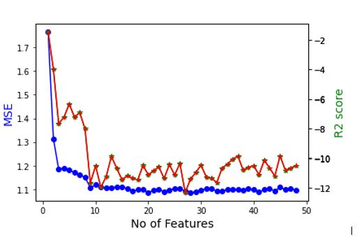

```python
from IPython.display import Image
Image(filename='RandomForestFeaturesVsMSE.jpg')
```

**Observations:** MSE remained more or less constant when the number of features >= 20

```python
'''
RandomForest Regression with Top 20 features With Normalization
'''
newsNormalizedDF = getNormalizeDataFrame(newsRFDF)
xTrain, yTrain, xTest, yTest = splitData(newsNormalizedDF,trainingRows, testingRows)
rfReg = fitModel(xTrain,yTrain, modelName = 'randomForest')
noOfFeatures = 20
topFeaturesDF = getTopFeatures(rfReg, noOfFeatures, colNameList, modelName = 'randomForest')
newsTopFeaturesDF = getDFWithTopFeatures(topFeaturesDF, newsNormalizedDF)

xTrain, yTrain, xTest, yTest = splitData(newsTopFeaturesDF,trainingRows, testingRows)
rfReg = fitModel(xTrain,yTrain, modelName = 'randomForest')
yRFPredict = predictModel(rfReg, xTest)
rfMSE = meanSquareErr(yRFPredict,yTest)
rfR2 = r2Score(yRFPredict,yTest)
rfAdjR2 = adjR2Score(xTest, rfR2)
accScore = "NA"
resultsDF = resultsDF.append({"Description" : "RandomForestRegression",
                              "Features" :"Top 20",
                              "MSE":rfMSE,
                              "R2" : rfR2,
                              "AdjR2" : rfAdjR2,
                              "AccuracyScore": accScore},
                             ignore_index = True
                             )


'''
Printing resultsDF
'''
resultsDF
```

|  | Description | Features | MSE | R2 | AdjR2 | AccuracyScore |
| --- | --- | --- | --- | --- | --- | --- |
| 0 | LinearRegression | All | 1.431228e+08 | -42.915146 | -43.178191 | NA |
| 1 | LinearRegression | Normalized | 1.058737e+00 | -42.915146 | -43.178191 | NA |
| 2 | LinearRegression | Top 20 | 1.060123e+00 | -47.684181 | -47.782643 | NA |
| 3 | LogisticRegression | All | 3.880928e-01 | -0.617326 | -0.627013 | 61.19071644803229 |
| 4 | LogisticRegression | All Normalized | 3.446014e-01 | -0.396891 | -0.405258 | 65.53985872855701 |
| 5 | LogisticRegression | Top 20 | 3.494450e-01 | -0.420013 | -0.422884 | 65.05549949545913 |
| 6 | RandomForestRegression | All | 1.488422e+08 | -10.765868 | -10.836344 | NA |
| 7 | RandomForestRegression | Normalized | 1.091596e+00 | -11.507375 | -11.582293 | NA |
| 8 | RandomForestRegression | Top 20 | 1.096139e+00 | -10.587011 | -10.610446 | NA |

```python
'''
Listing the top 20 features of RandomForest Regression Model
'''
topFeaturesDF.iloc[0:21,:]
```

|  | FeatureName | Coefficient |
| --- | --- | --- |
| 26 | kw_avg_avg | 0.093425 |
| 25 | kw_max_avg | 0.070434 |
| 2 | n_tokens_content | 0.060378 |
| 40 | LDA_02 | 0.040553 |
| 38 | LDA_00 | 0.037862 |
| 0 | timedelta | 0.034572 |
| 42 | LDA_04 | 0.032049 |
| 41 | LDA_03 | 0.030928 |
| 3 | n_unique_tokens | 0.030688 |
| 29 | self_reference_avg_sharess | 0.029398 |
| 23 | kw_avg_max | 0.027556 |
| 10 | average_token_length | 0.025525 |
| 28 | self_reference_max_shares | 0.025488 |
| 6 | num_hrefs | 0.024245 |
| 5 | n_non_stop_unique_tokens | 0.023437 |
| 20 | kw_avg_min | 0.023249 |
| 39 | LDA_01 | 0.022743 |
| 27 | self_reference_min_shares | 0.020959 |
| 24 | kw_min_avg | 0.020737 |
| 49 | avg_positive_polarity | 0.019739 |

**Fitting PCA for whole dataset for normalized data**

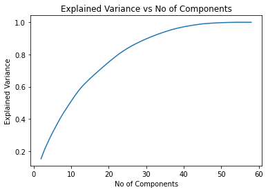

```python
'''
Principal Component Analysis (PCA)

n_components from 2 to whole number of components.
'''

newsNormalizedDF = getNormalizeDataFrame(newsDF)
newsX = newsNormalizedDF.iloc[:,0:-1]
newsY = newsNormalizedDF.iloc[:,-1]

pcaResultsDF = pd.DataFrame(columns = ["Components","Explained Variance"])
for n in range(2,newsX.shape[1]):
    pca = PCA(n_components = n)
    pcaTransformed = pca.fit_transform(newsX)
    pcaResultsDF = pcaResultsDF.append({"Components" : int(n), "Explained Variance" : sum(pca.explained_variance_ratio_)}, ignore_index = True)

plt.plot(pcaResultsDF["Components"], pcaResultsDF["Explained Variance"])
plt.xlabel("No of Components")
plt.ylabel("Explained Variance")
plt.title("Explained Variance vs No of Components")
```

**Observations:** Almost 75% of the variance can explained by PCA when n_components >= 20.

**Fitting PCA (n_components = 2) to see the distribution of the categorized shares.**

```
Variance explained : 0.15260940887366103
```

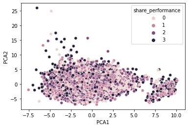

```python
'''
Principal Component Analysis (PCA)

n_components = 2
'''

'''
Categorizing shares to Low ( < 25 percentile), Average ( > 25 and < 50), Good ( >50 and <75) and Excellent ( > 75)
'''
newsShares = newsDF["shares"]
shareLabel = []
newsShares25per = np.percentile(newsShares,25)
newsShares50per = np.percentile(newsShares,50)
newsShares75per = np.percentile(newsShares,75)
for share in newsShares:
    if share < newsShares25per:
        shareLabel.append('Low')
    elif share >= newsShares25per and share < newsShares50per:
        shareLabel.append('Average')
    elif share >= newsShares50per and share < newsShares75per:
        shareLabel.append('Good')
    #share >= np.percentile(newsShares,75):
    else:
        shareLabel.append('Excellent')

newsDF1 = pd.concat([newsDF, pd.DataFrame(shareLabel, columns=['share_performance'])], axis=1)
del newsDF1["shares"]

newsDF1["share_performance"] = pd.factorize(newsDF1['share_performance'])[0]


'''
Applying PCA (n_components = 2) for the normalized data
'''

newsNormalizedDF = getNormalizeDataFrame(newsDF)
newsX = newsNormalizedDF.iloc[:,0:-1]
newsY = newsDF1["share_performance"]

pca = PCA(n_components = 2)
pcaTransformed = pca.fit_transform(newsX)
print('Variance explained :',sum(pca.explained_variance_ratio_))
pcaDF = pd.DataFrame(data = pcaTransformed, columns = ["PCA1","PCA2"])

finalDf = pd.concat([pcaDF, newsY], axis = 1)

sns.scatterplot(x = 'PCA1', y = 'PCA2', hue = 'share_performance', data = finalDf)
```

**Using PCA(n_components = 20) transformed data and applying Linear, Logistic and RandomForest Regression Models to check if there is any improvement in accuracy or r2 values.**

```python
'''
Generating column names for PCA components and transforming the dataframe interms of PCA
for applying models to the PCA transformed data
'''
pcaColNames = []
for c in range(1,21):
    pcaColNames.append("PCA"+str(c))

pca = PCA(n_components = 20)
pcaTransformed = pca.fit_transform(newsX)
pcaDF = pd.DataFrame(data = pcaTransformed, columns = pcaColNames)
finalDf = pd.concat([pcaDF, newsY], axis = 1)
```

```python
'''
Applying Linear Regression on PCA (n_components = 20) transformed dataset
'''
xTrain, yTrain, xTest, yTest = splitData(finalDf,trainingRows, testingRows)
linearReg = fitModel(xTrain,yTrain, modelName = 'linear')
yLinearRegPredict = predictModel(linearReg, xTest)
linearMSE = meanSquareErr(yLinearRegPredict,yTest)
linearR2 = r2Score(yLinearRegPredict,yTest)
linearAdjR2 = adjR2Score(xTest, linearR2)

resultsDF = resultsDF.append({"Description" : "LinearRegression",
                              "Features" :"20 PCA",
                              "MSE":linearMSE,
                              "R2" : linearR2,
                              "AdjR2" : linearAdjR2},
                             ignore_index = True
                             )

'''
Applying Logistic Regression on PCA (n_components = 20) transformed dataset
'''

finalDf['shares'] = (finalDf['shares'] >= finalDf['shares'].median()).astype(int)
xTrain, yTrain, xTest, yTest = splitData(finalDf,trainingRows, testingRows)
logReg = fitModel(xTrain,yTrain, modelName = 'logistic')
yLogRegPredict = predictModel(logReg, xTest)
logMSE = meanSquareErr(yLogRegPredict,yTest)
logR2 = r2Score(yLogRegPredict,yTest)
logAdjR2 = adjR2Score(xTest, logR2)
accScore = accuracyScore(yLogRegPredict, yTest)


resultsDF = resultsDF.append({"Description" : "LogisticRegression PCA",
                              "Features" :"20 PCA",
                              "MSE":logMSE,
                              "R2" : logR2,
                              "AdjR2" : logAdjR2,
                              "AccuracyScore" : accScore},
                             ignore_index = True
                             )

'''
Applying Random Forest Regression on PCA (n_components = 20) transformed dataset
'''

finalDf = pd.concat([pcaDF, newsY], axis = 1)
xTrain, yTrain, xTest, yTest = splitData(finalDf,trainingRows, testingRows)
rfReg = fitModel(xTrain,yTrain, modelName = 'randomForest')
yRFPredict = predictModel(rfReg, xTest)
rfMSE = meanSquareErr(yRFPredict,yTest)
rfR2 = r2Score(yRFPredict,yTest)
rfAjdR2 = adjR2Score(xTest, rfR2)


resultsDF = resultsDF.append({"Description" : "RandomForestRegression PCA",
                              "Features" :"20 PCA",
                              "MSE":rfMSE,
                              "R2" : rfR2,
                              "AdjR2" : rfAjdR2},
                             ignore_index = True
                             )

'''
Printing resultsDF
'''
resultsDF
```

|  | Description | Features | MSE | R2 | AdjR2 | AccuracyScore |
| --- | --- | --- | --- | --- | --- | --- |
| 0 | LinearRegression | All | 1.431228e+08 | -42.915146 | -43.178191 | NA |
| 1 | LinearRegression | Normalized | 1.058737e+00 | -42.915146 | -43.178191 | NA |
| 2 | LinearRegression | Top 20 | 1.060123e+00 | -47.684181 | -47.782643 | NA |
| 3 | LogisticRegression | All | 3.880928e-01 | -0.617326 | -0.627013 | 61.19071644803229 |
| 4 | LogisticRegression | All Normalized | 3.446014e-01 | -0.396891 | -0.405258 | 65.53985872855701 |
| 5 | LogisticRegression | Top 20 | 3.494450e-01 | -0.420013 | -0.422884 | 65.05549949545913 |
| 6 | RandomForestRegression | All | 1.488422e+08 | -10.765868 | -10.836344 | NA |
| 7 | RandomForestRegression | Normalized | 1.091596e+00 | -11.507375 | -11.582293 | NA |
| 8 | RandomForestRegression | Top 20 | 1.096139e+00 | -10.587011 | -10.610446 | NA |
| 9 | LinearRegression | 20 PCA | 1.064824e+00 | -63.283256 | -63.413266 | NaN |
| 10 | LogisticRegression PCA | 20 PCA | 3.627649e-01 | -0.512158 | -0.515216 | 63.72351160443996 |
| 11 | RandomForestRegression PCA | 20 PCA | 1.109721e+00 | -12.008132 | -12.034441 | NaN |

**Observations:** Applying regression models on PCA has not resulted in any improvement of the prediction of shares

### Applying Classifier Models

```python
'''
Categorizing shares to Low ( < 25 percentile), Average ( > 25 and < 50), Good ( >50 and <75) and Excellent ( > 75)
'''
newsShares = newsDF["shares"]
shareLabel = []
newsShares25per = np.percentile(newsShares,25)
newsShares50per = np.percentile(newsShares,50)
newsShares75per = np.percentile(newsShares,75)
for share in newsShares:
    if share < newsShares25per:
        shareLabel.append('Low')
    elif share >= newsShares25per and share < newsShares50per:
        shareLabel.append('Average')
    elif share >= newsShares50per and share < newsShares75per:
        shareLabel.append('Good')
    #share >= np.percentile(newsShares,75):
    else:
        shareLabel.append('Excellent')

newsDF1 = pd.concat([newsDF, pd.DataFrame(shareLabel, columns=['share_performance'])], axis=1)
del newsDF1["shares"]

newsDF1["share_performance"] = pd.factorize(newsDF1['share_performance'])[0]
```

**Applying RandomForest Classification model on the dataset**

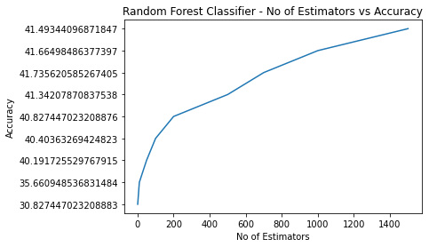

```python
'''
RandomForest Classifier (n_estimators)
'''
n_list = [1, 10, 50, 100, 200, 500, 700, 1000, 1500]
xTrain, yTrain, xTest, yTest = splitData(newsDF1,trainingRows, testingRows)
resultsRFC = pd.DataFrame(columns = ["No Of Estimators", "Accuracy"])
for n_estimator in n_list:
    rfClassifier = RandomForestClassifier(n_estimators=n_estimator)
    rfClassifier.fit(xTrain, yTrain)
    y_pred=rfClassifier.predict(xTest)
    rfcMSE = meanSquareErr(y_pred,yTest)
    rfcR2 = r2Score(y_pred,yTest)
    rfcAdjR2 = adjR2Score(xTest, rfcR2)
    accScore = accuracyScore(y_pred, yTest)
    resultsRFC = resultsRFC.append({"No Of Estimators":n_estimator, "Accuracy":accScore}, ignore_index = True)

plt.plot(resultsRFC["No Of Estimators"], resultsRFC["Accuracy"])
plt.xlabel('No of Estimators')
plt.ylabel('Accuracy')
plt.title('Random Forest Classifier - No of Estimators vs Accuracy')
```

**Observations:** Accuracy of more than 40.5% is attained when the number of estimators >=200

```python
'''
RandomForest Classifier (n_estimators = 200)
'''
rfClassifier = RandomForestClassifier(n_estimators=200)
xTrain, yTrain, xTest, yTest = splitData(newsDF1,trainingRows, testingRows)
rfClassifier.fit(xTrain, yTrain)
y_pred=rfClassifier.predict(xTest)
rfcMSE = meanSquareErr(y_pred,yTest)
rfcR2 = r2Score(y_pred,yTest)
rfcAdjR2 = adjR2Score(xTest, rfcR2)
accScore = accuracyScore(y_pred, yTest)

resultsDF = resultsDF.append({"Description" : "RandomForestClassifier",
                              "Features" :"All",
                              "MSE":rfcMSE,
                              "R2" : rfcR2,
                              "AdjR2" : rfcAdjR2,
                              "AccuracyScore" : accScore},
                             ignore_index = True
                             )

'''
Printing resultsDF
'''
resultsDF
```

|  | Description | Features | MSE | R2 | AdjR2 | AccuracyScore |
| --- | --- | --- | --- | --- | --- | --- |
| 0 | LinearRegression | All | 1.431228e+08 | -42.915146 | -43.178191 | NA |
| 1 | LinearRegression | Normalized | 1.058737e+00 | -42.915146 | -43.178191 | NA |
| 2 | LinearRegression | Top 20 | 1.060123e+00 | -47.684181 | -47.782643 | NA |
| 3 | LogisticRegression | All | 3.880928e-01 | -0.617326 | -0.627013 | 61.19071644803229 |
| 4 | LogisticRegression | All Normalized | 3.446014e-01 | -0.396891 | -0.405258 | 65.53985872855701 |
| 5 | LogisticRegression | Top 20 | 3.494450e-01 | -0.420013 | -0.422884 | 65.05549949545913 |
| 6 | RandomForestRegression | All | 1.488422e+08 | -10.765868 | -10.836344 | NA |
| 7 | RandomForestRegression | Normalized | 1.091596e+00 | -11.507375 | -11.582293 | NA |
| 8 | RandomForestRegression | Top 20 | 1.096139e+00 | -10.587011 | -10.610446 | NA |
| 9 | LinearRegression | 20 PCA | 1.064824e+00 | -63.283256 | -63.413266 | NaN |
| 10 | LogisticRegression PCA | 20 PCA | 3.627649e-01 | -0.512158 | -0.515216 | 63.72351160443996 |
| 11 | RandomForestRegression PCA | 20 PCA | 1.109721e+00 | -12.008132 | -12.034441 | NaN |
| 12 | RandomForestClassifier | All | 2.265590e+00 | -0.249528 | -0.257013 | 41.79616548940464 |

**Applying K-Nearest Neighbour Classification model on the dataset**

```python
'''
K-NearestNeighbour Classifier (n_neighbors)
'''
xTrain, yTrain, xTest, yTest = splitData(newsDF1,trainingRows, testingRows)
resultsKNN = pd.DataFrame(columns = ["No Of Neighbours", "Accuracy"])
for n_neighbor in range(1,200,5):
    knnClassifier = KNeighborsClassifier(n_neighbors = n_neighbor)
    knnClassifier.fit(xTrain, yTrain)
    y_pred=knnClassifier.predict(xTest)
    knnMSE = meanSquareErr(y_pred,yTest)
    knnR2 = r2Score(y_pred,yTest)
    knnAdjR2 = adjR2Score(xTest, rfcR2)
    accScore = accuracyScore(y_pred, yTest)
    resultsKNN = resultsKNN.append({"No Of Neighbours":n_neighbor, "Accuracy":accScore}, ignore_index = True)

plt.plot(resultsKNN["No Of Neighbours"], resultsKNN["Accuracy"])
plt.xlabel('No of Neighbours')
plt.ylabel('Accuracy')
plt.title('KNN Classifier - No of Neighbours vs Accuracy')
```

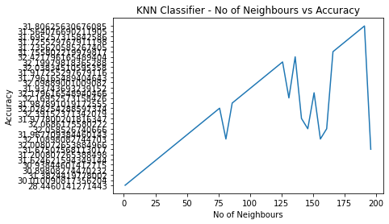

```python
from IPython.display import Image
Image(filename='KNNClassifier_NeighboursVsAccuracy.png')
```

```python
'''
K-NearestNeighbour Classifier (n_estimators = 100)
'''
knnClassifier = KNeighborsClassifier(n_neighbors = 100)
xTrain, yTrain, xTest, yTest = splitData(newsDF1,trainingRows, testingRows)
knnClassifier.fit(xTrain, yTrain)
y_pred=knnClassifier.predict(xTest)
knnMSE = meanSquareErr(y_pred,yTest)
knnR2 = r2Score(y_pred,yTest)
knnAdjR2 = adjR2Score(xTest, rfcR2)
accScore = accuracyScore(y_pred, yTest)

resultsDF = resultsDF.append({"Description" : "KNN Classifier",
                              "Features" :"All",
                              "MSE":knnMSE,
                              "R2" : knnR2,
                              "AdjR2" : knnAdjR2,
                              "AccuracyScore" : accScore},
                             ignore_index = True
                             )

'''
Printing resultsDF
'''
resultsDF
```

|  | Description | Features | MSE | R2 | AdjR2 | AccuracyScore |
| --- | --- | --- | --- | --- | --- | --- |
| 0 | LinearRegression | All | 1.431228e+08 | -42.915146 | -43.178191 | NA |
| 1 | LinearRegression | Normalized | 1.058737e+00 | -42.915146 | -43.178191 | NA |
| 2 | LinearRegression | Top 20 | 1.060123e+00 | -47.684181 | -47.782643 | NA |
| 3 | LogisticRegression | All | 3.880928e-01 | -0.617326 | -0.627013 | 61.19071644803229 |
| 4 | LogisticRegression | All Normalized | 3.446014e-01 | -0.396891 | -0.405258 | 65.53985872855701 |
| 5 | LogisticRegression | Top 20 | 3.494450e-01 | -0.420013 | -0.422884 | 65.05549949545913 |
| 6 | RandomForestRegression | All | 1.488422e+08 | -10.765868 | -10.836344 | NA |
| 7 | RandomForestRegression | Normalized | 1.091596e+00 | -11.507375 | -11.582293 | NA |
| 8 | RandomForestRegression | Top 20 | 1.096139e+00 | -10.587011 | -10.610446 | NA |
| 9 | LinearRegression | 20 PCA | 1.064824e+00 | -63.283256 | -63.413266 | NaN |
| 10 | LogisticRegression PCA | 20 PCA | 3.627649e-01 | -0.512158 | -0.515216 | 63.72351160443996 |
| 11 | RandomForestRegression PCA | 20 PCA | 1.109721e+00 | -12.008132 | -12.034441 | NaN |
| 12 | RandomForestClassifier | All | 2.265590e+00 | -0.249528 | -0.257013 | 41.79616548940464 |
| 13 | KNN Classifier | All | 2.818870e+00 | -0.441154 | -0.257013 | 33.84460141271443 |

## Conclusions

1. Logistic Regression model has given higher accuracy of 65.53% for the dataset in predicting the number of shares.
2. RandomForest Classifier has given accuracy of 41.79% when categorized the shares to Low, Avg, Good and Excellent based on the percentiles.
3. For most of the regression models, the adjusted R2 remained the same, even when the model is built using the top 20 features based on the coefficients or importance values.